# Comparing effectiveness of different embedding methods for finding clusters in papers from arXiv.org

- Our goal is to find a small number of clusters that effectively distinguish mathematics papers
- We analyse abstracts from ~15,000 papers split into 30 subjects

# Our data

```python
arxiv = pd.read_pickle('data/arxiv.pkl')
arxiv.head()
```

|  | Abstract | Code |
| --- | --- | --- |
| 0 | [show, hierarchy, intersection, rigidity, prop... | 53 |
| 1 | [note, time, collision, independent, Brownian,... | 60 |
| 2 | [article, proof, results, Blanc, Finite, Abeli... | 14 |
| 3 | [discuss, asymptotic, asymptotic_behaviour, be... | 05 |
| 4 | [smooth, smooth_projective, projective, projec... | 14 |

- There are 14402 papers in our `arxiv` dataframe
- Each paper is tagged with one of 30 codes
- There are 18216 in our vocabulary

# One-hot representations

We start with the most naive approach. Embed each paper as sum of the one-hot vectors of the words it contains. Simple as that.

```python
X_oh = k_means_data_as_one_hot_from_df(arxiv, vocab)
print('One-hot representation has shape', X_oh.shape)
```

```
One-hot representation has shape (14402, 18216)
```

# Word-to-vec representations

Similar approach, only now we use word-to-vec embeddings from a pre-trained word-to-vec model to embed words.

```python
X_w2v = k_means_data_as_w2v_from_abstracts(ab_list, w2v)
print('Word-to-vec representation has shape', X_w2v.shape)
```

```
Word-to-vec representation has shape (14402, 50)
```

# TFIDF representations

TFIDF is a means to assign relevance to words in the vocabulary by measuring

- how often a word appears (Term Frequency)
- how spread out that word is across the corpus of text (Inverse Document Frequency)

```python
max_features = 10000
vectorizer = TfidfVectorizer(max_df=0.5, max_features=max_features,
                             min_df=2, stop_words='english',
                             use_idf=True)

X_tfidf = vectorizer.fit_transform(abs_corpus)
print('Tf-Idf representation has shape', X_tfidf.shape)
```

```
Tf-Idf representation has shape (14402, 10000)
```

# Latent Semantic Analysis (LSA)

The TFIDF data still has 10,000-dimensional vectors. The idea behind LSA is to use the singular value decomposition to learn the a smaller number of important *concepts* and just use those.

```python
n_components = 20
svd = TruncatedSVD(n_components)
normalizer = Normalizer(copy=False)
lsa = make_pipeline(svd, normalizer)

X_lsa = lsa.fit_transform(X_tfidf)
print('LSA representation has shape', X_lsa.shape)
```

```
LSA representation has shape (14402, 20)
```

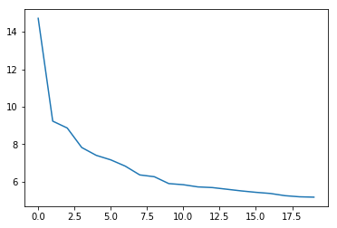

```python
plt.plot(svd.singular_values_)
plt.show()
```

# Clusters: K-means algorithm

- Use the k-means algorithm to find clusters in the data
- Use V-measure to see which embedding is most effective

## Evaluation metrics

- A clustering result satisfies **homogeneity** if all of its clusters contain only data points which are members of a single class.
- A clustering result satisfies **completeness** if all the data points that are members of a given class are elements of the same cluster.
- The **V-measure** is the harmonic mean between homogeneity and completeness

  ```
  v = 2 * (homogeneity * completeness) / (homogeneity + completeness)
  ```

## One-hot

```python
km_oh = MiniBatchKMeans(n_clusters=len(codes), init='k-means++', batch_size=1000)
```

Note `MiniBatchKMeans` is used here as one-hot representation high-dimensional.

```python
km_oh.fit(X_oh)
```

```
MiniBatchKMeans(batch_size=1000, compute_labels=True, init='k-means++',
        init_size=None, max_iter=100, max_no_improvement=10, n_clusters=30,
        n_init=3, random_state=None, reassignment_ratio=0.01, tol=0.0,
        verbose=0)
```

```python
print("Homogeneity: %0.3f" % metrics.homogeneity_score(labels, km_oh.labels_))
print("Completeness: %0.3f" % metrics.completeness_score(labels, km_oh.labels_))
print("V-measure: %0.3f" % metrics.v_measure_score(labels, km_oh.labels_))
```

```
Homogeneity: 0.220
Completeness: 0.301
V-measure: 0.254
```

# Word-to-vec

```python
km_w2v = KMeans(n_clusters=len(codes))
```

Here we don't need to employ `MiniBatchKMeans` as our word-to-vec embedding is of relatively low-dimension.

```python
km_w2v.fit(X_w2v)
```

```
KMeans(algorithm='auto', copy_x=True, init='k-means++', max_iter=300,
    n_clusters=30, n_init=10, n_jobs=1, precompute_distances='auto',
    random_state=None, tol=0.0001, verbose=0)
```

```python
print("Homogeneity: %0.3f" % metrics.homogeneity_score(labels, km_w2v.labels_))
print("Completeness: %0.3f" % metrics.completeness_score(labels, km_w2v.labels_))
print("V-measure: %0.3f" % metrics.v_measure_score(labels, km_w2v.labels_))
```

```
Homogeneity: 0.515
Completeness: 0.376
V-measure: 0.434
```

## TFIDF

```python
km_tfidf = MiniBatchKMeans(n_clusters=len(codes), init='k-means++', batch_size=1000)
```

```python
km_tfidf.fit(X_tfidf)
```

```
MiniBatchKMeans(batch_size=1000, compute_labels=True, init='k-means++',
        init_size=None, max_iter=100, max_no_improvement=10, n_clusters=30,
        n_init=3, random_state=None, reassignment_ratio=0.01, tol=0.0,
        verbose=0)
```

```python
print("Homogeneity: %0.3f" % metrics.homogeneity_score(labels, km_tfidf.labels_))
print("Completeness: %0.3f" % metrics.completeness_score(labels, km_tfidf.labels_))
print("V-measure: %0.3f" % metrics.v_measure_score(labels, km_tfidf.labels_))
```

```
Homogeneity: 0.516
Completeness: 0.372
V-measure: 0.432
```

## LSA

```python
km_lsa = KMeans(n_clusters=len(codes))
```

```python
km_lsa.fit(X_lsa)
```

```
KMeans(algorithm='auto', copy_x=True, init='k-means++', max_iter=300,
    n_clusters=30, n_init=10, n_jobs=1, precompute_distances='auto',
    random_state=None, tol=0.0001, verbose=0)
```

```python
print("Homogeneity: %0.3f" % metrics.homogeneity_score(labels, km_lsa.labels_))
print("Completeness: %0.3f" % metrics.completeness_score(labels, km_lsa.labels_))
print("V-measure: %0.3f" % metrics.v_measure_score(labels, km_lsa.labels_))
```

```
Homogeneity: 0.581
Completeness: 0.388
V-measure: 0.465
```

- This is our highest `V-measure`!
- LSA seems to be performing best on this data
- We should explore the hyperparameter space for further gains